# Practica_limpieza_y_analisis_de_datos

2023-02-01

[figure not shown]

# 1 1. Detalles de la actividad

## 1.1 1.1. Descripción

En esta práctica se elabora un caso práctico orientado a aprender a identificar los datos relevantes para un proyecto analítico y usar las herramientas de integración, limpieza, validación y análisis de las mismas.

## 1.2 1.2. Objetivos

- Aprender a aplicar los conocimientos adquiridos y su capacidad de resolución de problemas en entornos nuevos o poco conocidos dentro de contextos más amplios o multidisciplinares.
- Saber identificar los datos relevantes y los tratamientos necesarios (integración, limpieza y validación) para llevar a cabo un proyecto analítico.
- Aprender a analizar los datos adecuadamente para abordar la información contenida en los datos.
- Identificar la mejor representación de los resultados para aportar conclusiones sobre el problema planteado en el proceso analítico.
- Actuar con los principios éticos y legales relacionados con la manipulación de datos en función del ámbito de aplicación.
- Desarrollar las habilidades de aprendizaje que les permitan continuar estudiando de un modo que tendrá que ser en gran medida autodirigido o autónomo.
- Desarrollar la capacidad de búsqueda, gestión y uso de información y recursos en el ámbito de la ciencia de datos.

## 1.3 1.3. Competencias

- Capacidad para extraer, interpretar y analizar datos de diferentes entornos.
- Uso avanzado de las herramientas de programas estadísticos adecuados para los diferentes problemas de modelización, análisis y visualización de datos.
- Capacidad para proponer soluciones innovadoras y tomar decisiones.
- Capacidad para trabajar en equipos multidisciplinarios.

# 2 2.Resolución

## 2.1 2.1. Descripción del dataset

El conjunto de datos objeto de análisis se ha obtenido a partir de este enlace en [Kaggle](https://www.kaggle.com/datasets/rashikrahmanpritom/heart-attack-analysis-prediction-dataset?resource=download) y está constituido por 14 características (columnas) que presentan 303 registros de personas (filas).

Entre los campos de este conjunto de datos, encontramos los siguientes:

- **age :** Edad del paciente
- **sex :** Género: 1 = masculino; 0 = femenino
- **cp :** Tipo de dolor en el pecho (valores de 0 a 3)
  - Valor 0: angina típica
  - Valor 1: angina atípica
  - Valor 2: dolor no anginoso
  - Valor 3: asintomático
- **trtbps** : presión arterial en reposo (en mm Hg)
- **chol:** Colesterol en mg/dl obtenido a través del sensor de IMC
- **fbs :** Azúcar en sangre en ayunas > 120 mg/dl (1 = verdadero; 0 = falso)
- **restecg:** Resultados electrocardiográficos en reposo (Valores de 0 a 2)
  - Valor 0: Normal
  - Valor 1: Anomalía de la onda ST-T (inversiones de la onda T y/o elevación o depresión del ST de > 0,05 mV)
  - Valor 2: Muestra hipertrofia ventricular izquierda probable o definida según el criterio de Estes
- **thalachh** : Máxima frecuencia cardíaca alcanzada
- **exng :** 0= menos probabilidad de ataque cardíaco 1= más probabilidad de ataque cardíaco
- **oldpeak:** Depresión del ST inducida por el ejercicio relativo al descanso.
- **slp:** Pendiente de ST en el pico de ejercicio (Del 0 al 2).
  - Valor 0: Ascendiente
  - Valor 1: Plana
  - Valor 2: Descendente
- **caa:** Número de vasos principales (0-4) coloreados por fluorospía.
- **thall :** THAL. (Del 0 al 3). Esta escala no logre identificarla a que equivale cada valor
  - Valor 0:
  - Valor 1:
  - Valor 2:
  - Valor 3:
- **Output:** Variable de destino 0 = No tiene enfermedad cardiovascular. 1 = Tiene enfermedad cardiovascular.

```r
#cargue de las librerias que vamos a utilizar
library(Rcmdr) #trabajar con R commander
```

```r
library(ggplot2) # permite trabajar graficar, otra opción
library(lattice)# permite trabajar factores
library(moments)# permite trabajar factores
library(splines)#lebreria complementaria a las primeras
library(RcmdrMisc)#lebreria complementaria a las primeras
library(car)#lebreria complementaria a las primeras
library(carData)#lebreria complementaria a las primeras
library(sandwich)#lebreria complementaria a las primeras
```

## 2.2 2.2. Importancia y objetivos de los análisis

A partir de este conjunto de datos se plantea la problemática de determinar qué variables influyen más sobre determinar que personas pueden sufrir ataques cardíacos.

Además, se podrá proceder a crear modelos de regresión que permitan predecir que personas pueden sufrir ataques cardíacos en función de sus características y contrastes de hipótesis que ayuden a identificar propiedades interesantes en las muestras que puedan ser inferidas con respecto a la población.

Estos análisis adquieren una gran relevancia en casi cualquier sector relacionado con la salud, ya que con base a este diganostico los medicos especilistas de las diferentes areas del cuerpo podran atender y tratar a las personas para que no le genera cumplicaciones cardiacas al paciente. Igualmente conociendo este diagnostico se pueden generar estrategias para disminuir el riesgo de un ataque cardíaco modificando conductas que pueden aumentar el riesgo o tratando una enfermedad coronaria conocida. Los cambios para un estilo de vida saludable, que incluyen comer alimentos saludables, mantenerse activo, dejar de fumar, controlar el estrés y mantener un peso saludable, pueden ayudar a prevenir la enfermedad cardíaca. Incluso si ya tiene enfermedad coronaria, esos cambios pueden disminuir el riesgo de un ataque cardíaco.

## 2.3 2.3. Limpieza de los datos

Antes de comenzar con la limpieza de los datos, procedemos a realizar la lectura del fichero en formato CSV en el que se encuentran los datos. El resultado devuelto por la llamada a la función read.csv() será un objeto data.frame:

```r
# Lectura de datos
corazon <- read.csv("heart.csv", header = TRUE)
head(corazon[,1:5])
```

```
##   age sex cp trtbps chol
## 1  63   1  3    145  233
## 2  37   1  2    130  250
## 3  41   0  1    130  204
## 4  56   1  1    120  236
## 5  57   0  0    120  354
## 6  57   1  0    140  192
```

```r
# Tipo de dato asignado a cada campo
sapply(corazon, function(x) class(x))
```

```
##       age       sex        cp    trtbps      chol       fbs   restecg  thalachh
## "integer" "integer" "integer" "integer" "integer" "integer" "integer" "integer"
##      exng   oldpeak       slp       caa     thall    output
## "integer" "numeric" "integer" "integer" "integer" "integer"
```

Además, observamos cómo los tipos de datos asignados automáticamente por R a las variables se corresponden con el dominio de estas.

**Nota:** se tenia previsto que los valores desconocidos eran denotados en el dataset mediante el caracter ‘?’. y se pretendia realizar una sustitución de estos valores por una cadena vacía previa a la lectura, para que R marque estos valores desconocidos como NA (del inglés, Not Available). Esto simplificaría el manejo de los datos en los apartados posteriores, sin embargo el data set no contenia valores desconocidos.

### 2.3.1 2.3.1. Selección de los datos de interés

La gran mayoría de los atributos presentes en el conjunto de datos se corresponden con características que se reúnen de las diferentes personas y que fueron recogidos en forma de registros, por lo que será conveniente tenerlos en consideración durante la realización de los análisis. No se encontro caracterisitcas de las cuales se pudieran presindir de ellas, como para ser eliminadas.

### 2.3.2 2.3.2. Ceros y elementos vacíos

Comúnmente, se utilizan los ceros como centinela para indicar la ausencia de ciertos valores. Sin embargo, no es el caso de este conjunto de datos puesto que, como se comentó durante el apartado relativo a la lectura, no se encontraron valores desconocidos. Así, se procede verificar si los campos contienen elementos vacíos:

```r
# Números de valores desconocidos por campo
sapply(corazon, function(x) sum(is.na(x)))
```

```
##      age      sex       cp   trtbps     chol      fbs  restecg thalachh
##        0        0        0        0        0        0        0        0
##     exng  oldpeak      slp      caa    thall   output
##        0        0        0        0        0        0
```

Si fuese el caso de encontrar valores desconocidos, deberiamos decidir como manejar estos registros que contienen valores desconocidos para algún campo. Una opción podría ser eliminar esos registros que incluyen este tipo de valores, pero ello supondría desaprovechar información.

Como alternativa, se empleará un método de imputación de valores basado en la similitud o diferencia entre los registros: la imputación basada en k vecinos más próximos (en inglés, kNN-imputation). La elección de esta alternativa se realiza bajo la hipótesis de que nuestros registros guardan cierta relación. No obstante, es mejor trabajar con datos “aproximados” que con los propios elementos vacíos, ya que obtendremos análisis con menor margen de error.

A continuación, se realiza el ejemplo de como se debe realizar la imputación si ubiese campus vacios en todas las caracteristicas

```r
# Imputación de valores mediante la función kNN() del paquete VIM, no aparecerà el masaje de nada que imputar porque como se mencionaba

suppressWarnings(suppressMessages(library(VIM)))

corazon$age <- kNN(corazon)$age
corazon$sex <- kNN(corazon)$sex
corazon$cp <- kNN(corazon)$cp
corazon$trtbps  <- kNN(corazon)$trtbps
corazon$chol  <- kNN(corazon)$chol
corazon$fbs  <- kNN(corazon)$chol
corazon$restecg  <- kNN(corazon)$restecg
corazon$thalachh  <- kNN(corazon)$thalachh
corazon$exng   <- kNN(corazon)$exng
corazon$oldpeak  <- kNN(corazon)$oldpeak
corazon$slp  <- kNN(corazon)$slp
corazon$caa  <- kNN(corazon)$caa
corazon$thall  <- kNN(corazon)$thall
corazon$output  <- kNN(corazon)$output
sapply(corazon, function(x) sum(is.na(x)))
```

```
##      age      sex       cp   trtbps     chol      fbs  restecg thalachh
##        0        0        0        0        0        0        0        0
##     exng  oldpeak      slp      caa    thall   output
##        0        0        0        0        0        0
```

### 2.3.3 2.3.3. Valores extremos

Los valores extremos o outliers son aquellos que parecen no ser congruentes sin los comparamos con el resto de los datos. Para identificarlos, podemos hacer uso de dos vías: (1) representar un diagrama de caja por cada variable y ver qué valores distan mucho del rango intercuartílico (la caja) o (2) utilizar la función boxplots.stats() de R. Se utilizaran las 2 opciones:

A continuación se mostrarán sólo los valores atípicos para aquellas variables que los contienen:

**Variable** **presión arterial en reposo**

```r
# Valores atípicos para la variable trtbps
boxplot.stats(corazon$trtbps)$out
```

```
## [1] 172 178 180 180 200 174 192 178 180
```

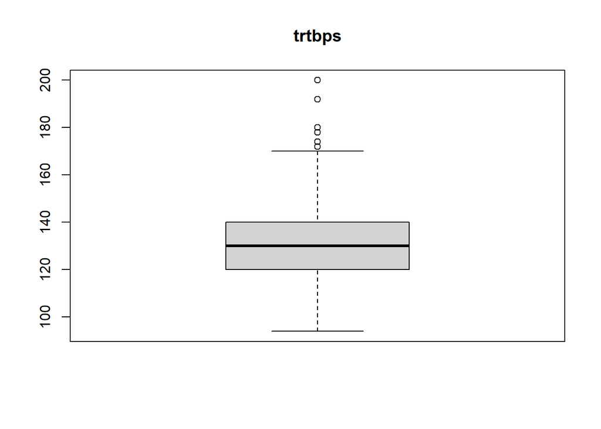

```r
# Diagrama de caja para la variable trtbp
boxplot(corazon$trtbps)
title("trtbps")
```

En la presión arterial en reposo, los valores fuera y alejados de la caja no se tratan de valores extremos que se traduzcan en error de inserción. Si lo vemos en un gráfico plot, se entiende mejor.

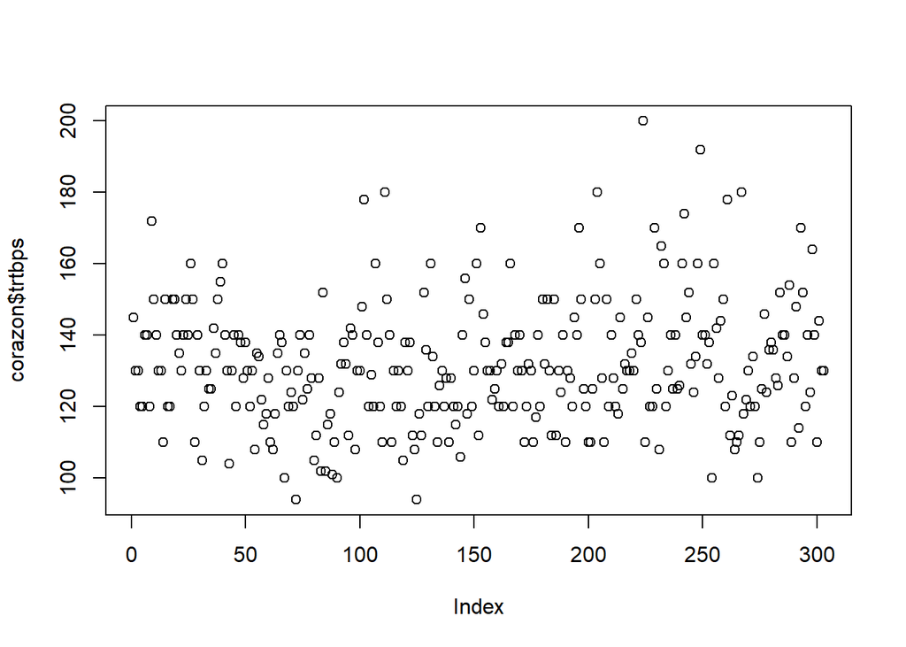

```r
plot(corazon$trtbps)
```

```r
#title("Presión arterial en reposo")
```

**Variable colestero**

```r
# Valores atípicos para la variable chol
boxplot.stats(corazon$chol)$out
```

```
## [1] 417 564 394 407 409
```

En los niveles de colesterol encontramos un caso donde el valor de estos son 564. Aunque es un valor muy alto, tiene sentido ya que esta persona indica enfermedad (valor output = 1) osea que tiene enfermedad cardiovascular.

```r
corazon[which(corazon$chol>500),]
```

```
##    age sex cp trtbps chol fbs restecg thalachh exng oldpeak slp caa thall
## 86  67   0  2    115  564 564       0      160    0     1.6   1   0     3
##    output
## 86      1
```

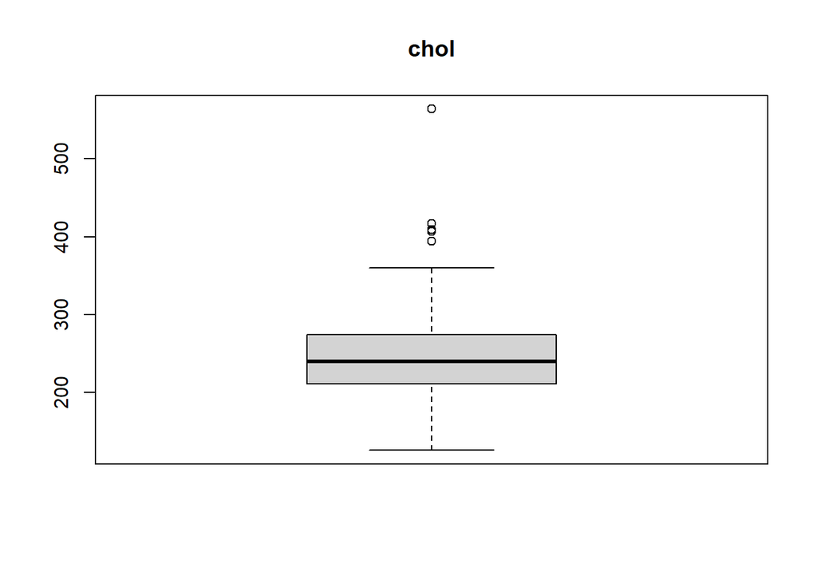

```r
# Diagrama de caja para la variable chol
boxplot(corazon$chol)
title("chol")
```

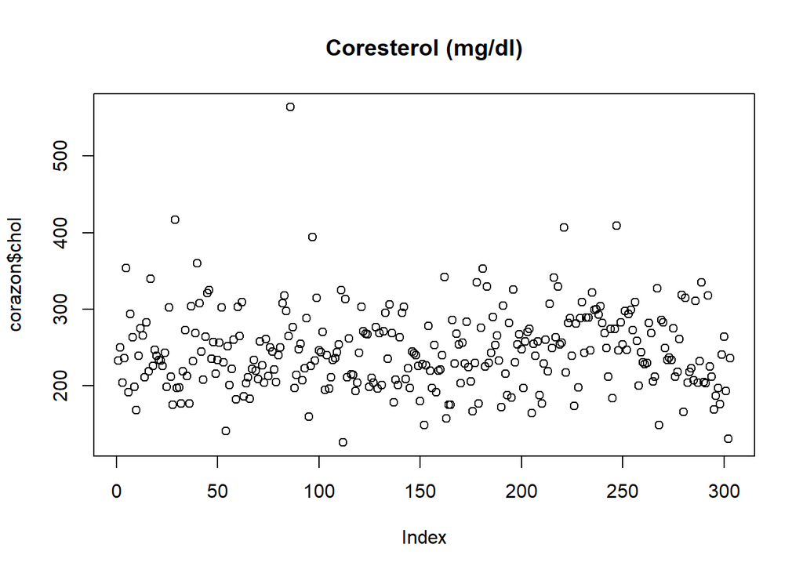

```r
plot(corazon$chol)
title("Coresterol (mg/dl)")
```

### 2.3.4 2.3.4. Exportación de los datos preprocesados

Despues de haber aplicado sobre el conjunto de datos inicial los procedimientos de integración, validación y limpieza anteriores, procedemos a guardar estos en un nuevo fichero denominado corazon_data_clean.csv:

```r
# Exportación de los datos limpios en .csv
write.csv(corazon, "corazon_data_clean.csv")
```

## 2.4 2.4. Análisis de los datos

### 2.4.1 2.4.1. Selección de los grupos de datos a analizar

A continuación, se seleccionan los grupos dentro de nuestro conjunto de datos que pueden resultar interesantes para analizar y/o comparar. No obstante, como se verá en el apartado consistente en la realización de pruebas estadísticas, no todos se utilizarán.

```r
# Agrupación por tipo de combustible
corazon.femenino <- corazon[corazon$sex == "0",]
corazon.masculino <- corazon[corazon$sex == "1",]
```

Para la selección de los grupos de datos analizar, tambien se puede apoyar realizando la relación que pueda existir entre las variables

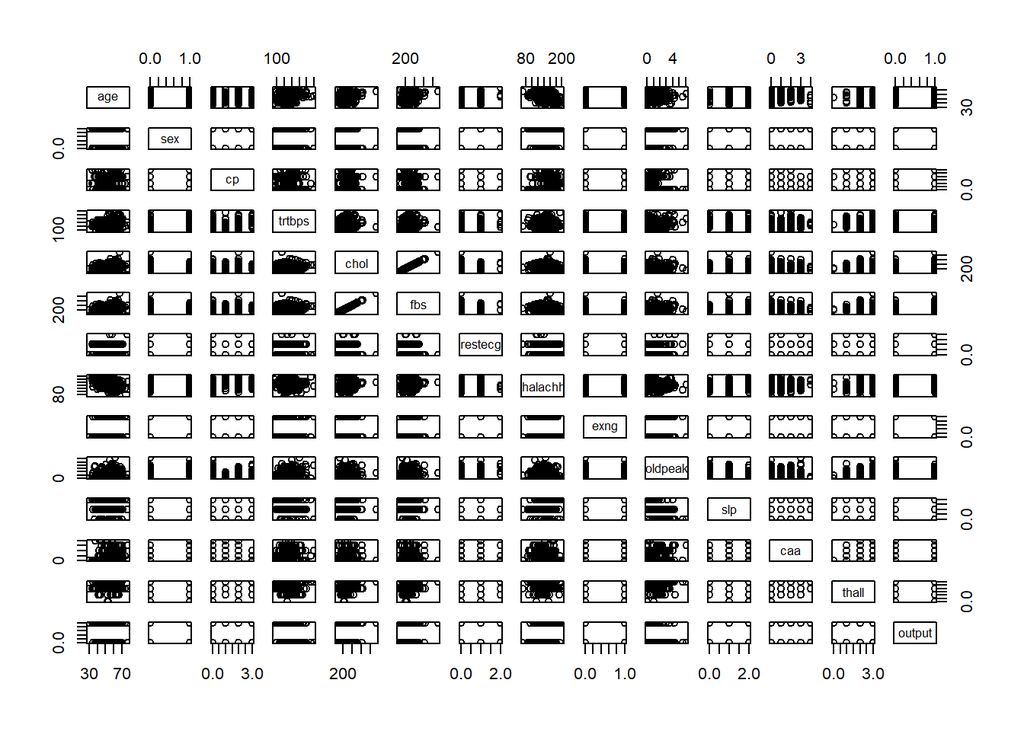

```r
corazon.numeric <- corazon[,unlist(lapply(corazon, is.numeric))]
plot(corazon.numeric)
```

A continuación se grafican algunas de las variables que nos permitirian ayudar a realizar la selección de los grupos.

Realizamos un grafica de barras para representar los valores de la variable sexo , para las etiquetas masculino y femenido

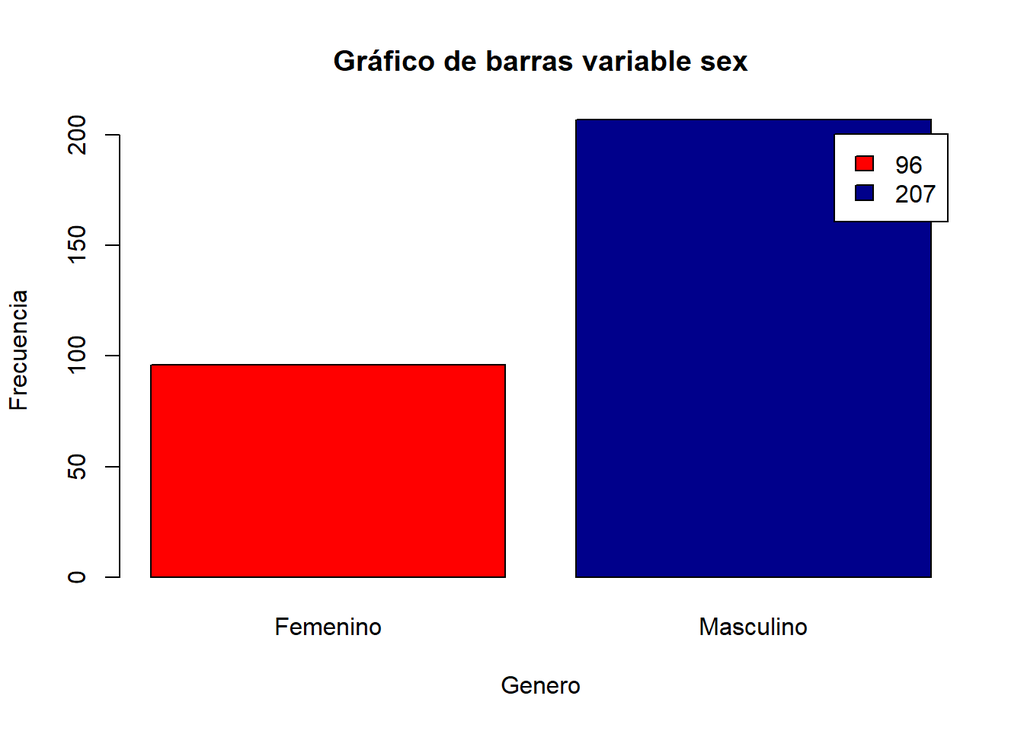

```r
barplot(table(corazon$sex),
        names.arg= c("Femenino", "Masculino"),
        main = "Gráfico de barras variable sex",
        xlab = "Genero", ylab = "Frecuencia",
        col = c( "red", "darkblue"),
        legend.text = table(corazon$sex))
```

Seguidamente se realiza un histograma para conocer la distribución de la variable edad .

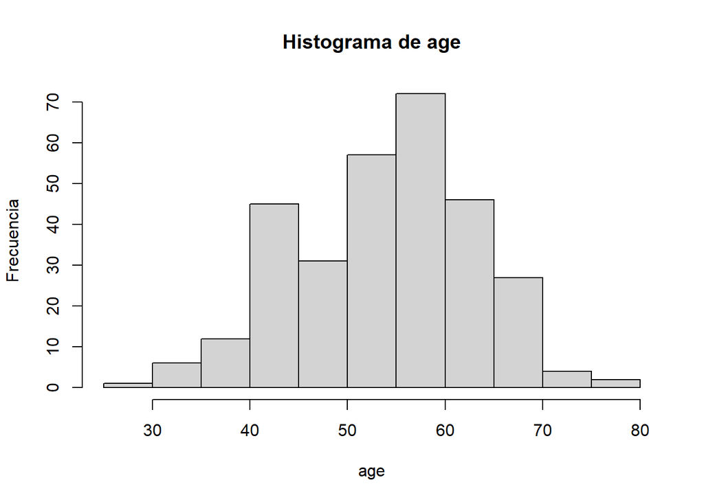

```r
hist(corazon$age, main = "Histograma de age", # Frecuencia
     xlab = "age", ylab = "Frecuencia")
```

Se ividencia que hay pico de 40 a 45 años, seguidamente se observa que hay mas parsonas con edades entre 50 y 60 años.

Seguidamente se realiza un histograma para conocer la distribución de la variable thalachh.

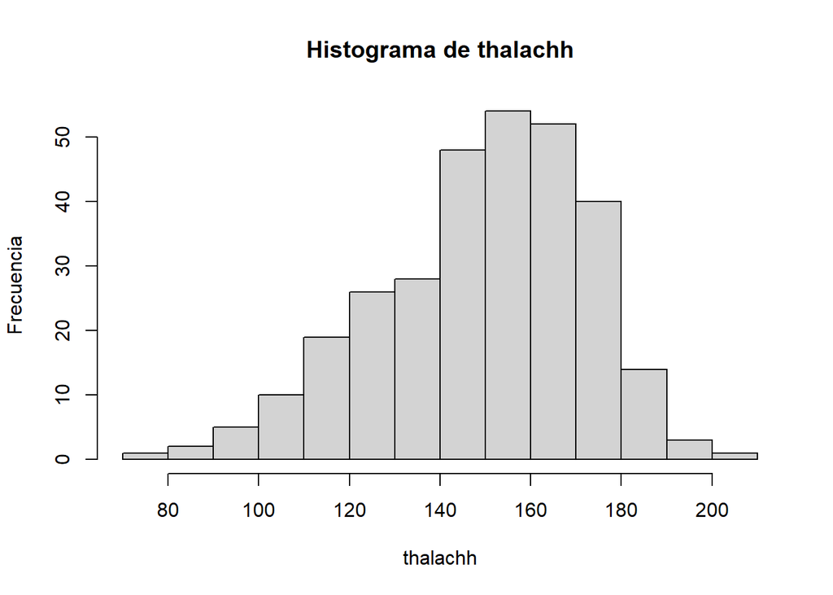

```r
hist(corazon$thalachh, main = "Histograma de thalachh", # Frecuencia
     xlab = "thalachh", ylab = "Frecuencia")
```

### 2.4.2 2.4.2 Comprobación de la normalidad y homogeneidad de la varianza

Para la comprobación de que los valores que toman nuestras variables cuantitativas provienen de una población distribuida normalmente, utilizaremos la prueba de normalidad de **Anderson-Darling.**

Así, se comprueba que para que cada prueba se obtiene un p-valor superior al nivel de significación prefijado $\alpha$ = 0, 05. Si esto se cumple, entonces se considera que variable en cuestión sigue una distribución normal.

```r
library(nortest)
alpha = 0.05
col.names = colnames(corazon)
for (i in 1:ncol(corazon)) {
  if (i == 1) cat("Variables que no siguen una distribución normal:\n \n")
  if (is.integer(corazon[,i]) | is.numeric(corazon[,i])) {
    p_val = ad.test(corazon[,i])$p.value
  if (p_val < alpha) {
  cat(col.names[i])
  # Formato de salida
  if (i < ncol(corazon) - 1) cat(", ")
  if (i %% 3 == 0) cat("\n")
}
}
}
```

```
## Variables que no siguen una distribución normal:
##
## age, sex, cp,
## trtbps, chol, fbs,
## restecg, thalachh, exng,
## oldpeak, slp, caa,
## thalloutput
```

Estudiamos ahora la homogeneidad de varianzas mediante la aplicación de un **test de Fligner-Killeen**. En este caso, estudiaremos la homogeneidad en cuanto al colesterol los grupos conformados por mujeres frente a los hombres.

```r
fligner.test(chol ~ sex, data = corazon)
```

```
##
##  Fligner-Killeen test of homogeneity of variances
##
## data:  chol by sex
## Fligner-Killeen:med chi-squared = 9.0547, df = 1, p-value = 0.00262
```

No podemos concluir que existe homogeneidad en la varianza de los dos grupos, ya que el p-valor resultante del test es menor al nivel de significancia 0.05 marcado por el nivel de confianza.

```r
fligner.test(age ~ sex, data = corazon)
```

```
##
##  Fligner-Killeen test of homogeneity of variances
##
## data:  age by sex
## Fligner-Killeen:med chi-squared = 0.517, df = 1, p-value = 0.4721
```

Podemos concluir que existe homogeneidad en la varianza de los dos grupos, ya que el p-valor resultante del test es mayor al nivel de significancia 0.05 marcado por el nivel de confianza.

## 2.5 2.5. Pruebas estadísticas

### 2.5.1 2.5.1. ¿Qué variables cuantitativas influyen más en el diagnostico?

En primer lugar, procedemos a realizar un análisis de correlación entre las distintas variables para determinar cuáles de ellas ejercen una mayor influencia sobre el el diganostico final del paciente.

Para ello, se utilizará el coeficiente de correlación de Spearman, puesto que hemos visto que tenemos datos que no siguen una distribución normal.

```r
corr_matrix <- matrix(nc = 2, nr = 0)
colnames(corr_matrix) <- c("estimate", "p-value")

# Calcular el coeficiente de correlación para cada variable cuantitativa
# con respecto al campo "output"

for (i in 1:(ncol(corazon.numeric) - 1)) {
  if (is.integer(corazon[,i]) | is.numeric(corazon[,i])) {
    spearman_test = cor.test(corazon[,i],
                    corazon[,length(corazon)],
                    method = "spearman",
                    exact = FALSE)
    corr_coef = spearman_test$estimate
    p_val = spearman_test$p.value
    # Add row to matrix
    pair = matrix(ncol = 2, nrow = 1)
    pair[1][1] = corr_coef
    pair[2][1] = p_val
    corr_matrix <- rbind(corr_matrix, pair)
    rownames(corr_matrix)[nrow(corr_matrix)] <- colnames(corazon)[i]
  }
}

par(mfrow=c(1,1))
print(corr_matrix)
```

```
##            estimate      p-value
## age      -0.2384001 2.749629e-05
## sex      -0.2809366 6.678692e-07
## cp        0.4608602 2.444718e-17
## trtbps   -0.1215928 3.437373e-02
## chol     -0.1208882 3.543860e-02
## fbs      -0.1208882 3.543860e-02
## restecg   0.1486115 9.581603e-03
## thalachh  0.4283699 5.938298e-15
## exng     -0.4367571 1.520814e-15
## oldpeak  -0.4214871 1.766192e-14
## slp       0.3714605 2.393250e-11
## caa      -0.4576075 4.351795e-17
## thall    -0.4032993 2.799358e-13
```

Así, identificamos cuáles son las variables más correlacionadas con el el diagnostico en función de su proximidad con los valores -1 y +1. Teniendo esto en cuenta, queda patente cómo la variable más relevante en la fijación del dianostico es el cp : **Tipo de dolor en el pecho del paciente**.

Nota. Para cada coeficiente de correlación se muestra también su p-valor asociado, puesto que éste puede dar información acerca del peso estadístico de la correlación obtenida.

La segunda prueba estadística que se aplicará consistirá en un contraste de hipótesis sobre dos muestras para determinar si el diagnostico es postivo dependiendo del tipo de Genero del que se trate (femenio o masculino). Para ello, tendremos dos muestras: la primera de ellas se corresponderá a los dianosticos de los pacientes mujeres, la segunda, con aquellos que pacientes hombres.

Se debe destacar que un test paramétrico como el que a continuación se utiliza necesita que los datos sean normales, si la muestra es de tamaño inferior a 30. Como en nuestro caso, n > 30, el contraste de hipótesis siguiente es válido (aunque podría utilizarse un test no paramétrico como el de Mann-Whitney, que podría resultar ser más eficiente para este caso).

```r
corazon.mujeres.diag <-
corazon[corazon$sex == "0",]$output
corazon.hombre.diag <-
corazon[corazon$sex == "1",]$output
```

Así, se plantea el siguiente contraste de hipótesis de dos muestras sobre la diferencia de medias, el cual es unilateral atendiendo a la formulación de la hipótesis alternativa

$H_0: \mu_1 - \mu_2 = 0$

donde µ1 es la media de la población de la que se extrae la primera muestra y µ2 es la media de la población de la que extrae la segunda. Así, tomaremos $\alpha$ = 0, 05.

```r
t.test(corazon.hombre.diag, corazon.mujeres.diag,
alternative = "less")
```

```
##
##  Welch Two Sample t-test
##
## data:  corazon.hombre.diag and corazon.mujeres.diag
## t = -5.3372, df = 209.95, p-value = 1.22e-07
## alternative hypothesis: true difference in means is less than 0
## 95 percent confidence interval:
##        -Inf -0.2076342
## sample estimates:
## mean of x mean of y
## 0.4492754 0.7500000
```

Puesto que obtenemos un p-valor menor que el valor de significación fijado, rechazamos la hipótesis nula. Por tanto, podemos concluir que, efectivamente, que es mas probable que diagnostico una persona es positivo, si es mujer.

### 2.5.3 **2.5.3. Modelo de regresión linea**

Tal y como se planteó en los objetivos de la actividad, resultará de mucho interés poder realizar predicciones sobre el diagnostico de enfermedad cardiovascular de una persona dadas sus características. Así, se calculará un modelo de regresión lineal utilizando regresores tanto cuantitativos como cualitativos con el que poder realizar las predicciones del diagnostico.

```r
# Regresores cuantitativos con mayor coeficiente
# de correlación con respecto al diagnostivo
frecuenciaArterial = corazon$thalachh


# Regresores cualitativos
tipodolor = corazon$cp
electrocardiograficosReposo = corazon$restecg
STEjercicio = corazon$slp

# Variable a predecir
dianostico = corazon$output
# Generación de varios modelos
modelo1 <- lm(output ~ cp + restecg + thalachh +slp, data = corazon)
modelo2 <- lm(output ~ cp + restecg + thalachh +slp +chol, data = corazon)
```

Para los anteriores modelos de regresión lineal múltiple obtenidos, podemos utilizar el coeficiente de determinación para medir la bondad de los ajustes y quedarnos con aquel modelo que mejor coeficiente presente

```r
# Tabla con los coeficientes de determinación de cada modelo
tabla.coeficientes <- matrix(c(1, summary(modelo1)$r.squared,
2, summary(modelo2)$r.squared),
ncol = 2, byrow = TRUE)

colnames(tabla.coeficientes) <- c("Modelo", "R^2")
print(tabla.coeficientes)
```

```
##      Modelo       R^2
## [1,]      1 0.3295705
## [2,]      2 0.3314125
```

```r
newdata <- data.frame(
cp = 3,
restecg = 0,
thalachh = 150,
slp = 0,
chol = 223)


# Predecir el precio
predict(modelo2, newdata)
```

```
##         1
## 0.6058435
```

## 2.6 **2.6.Conclusiones**

Como se ha visto, se han realizado diferentes tipos de pruebas estadísticas sobre un conjunto de datos que se correspondía con diferentes variables relativas al diagnostico de personas a sufrir o no enfermedades cardiacas, con motivo de cumplir con lo plnatado en la actividd. Para cada una de ellas, hemos podido ver cuáles son los resultados que arrojan (entre otros, mediante tablas) y qué conocimientos pueden extraerse a partir de ellas.

# 3 3.Referencia

- Calvo M, Subirats L, Pérez D (2019). Introducción a la limpieza y análisis de los datos. Editorial UOC.
- Tutorial de Github (https://guides.github.com/activities/hello-world/)
- Squire, Megan (2015). Clean Data. Packt Publishing Ltd.
- Jiawei Han, Micheine Kamber, Jian Pei (2012). Data mining: concepts and techniques. Morgan Kaufmann.
- Jason W. Osborne (2010). Data Cleaning Basics: Best Practices in Dealing with Extreme Scores. Newborn and Infant Nursing Reviews; 10 (1): pp. 1527-3369.
- Peter Dalgaard (2008). Introductory statistics with R. Springer Science & Business Media.
- Wes McKinney (2012). Python for Data Analysis. O Reilley Media, Inc.